# Airline On-Time Performance Data

## by João Victor Moreira de Figueiredo

## Introduction

Reporting carriers are required to (or voluntarily) report on-time data for flights they operate: on-time arrival and departure data for non-stop domestic flights by month and year, by carrier and by origin and destination airport. Includes scheduled and actual departure and arrival times, canceled and diverted flights, taxi-out and taxi-in times, causes of delay and cancellation, air time, and non-stop distance.

This project explore twelve months of data, starting at May 2019 to April 2020 totaling approximately 7 million flights.

## Preliminary Wrangling

```python
# import all packages and set plots to be embedded inline
import numpy as np
import pandas as pd
import matplotlib.pyplot as plt
import seaborn as sb
import requests

%matplotlib inline
```

### 1. Load the dataset

Access this [link](https://1drv.ms/u/s!ArfbtT2XOWRwhNV1m_wLJotkXAa76A?e=xlxbwe) to download the files that be scope of this project.

After download files, follow the next steps:

1. Create a folder named 'files' in root project
2. Inside files, create a folder named 'data'
3. Copy the twelve zip files inside the 'data' folder
4. The script bellow will descompress and rename the csv files

**Obs:** The script will take two minutes approximately to descompress all files

```python
import zipfile
import os
import time
import glob

if os.path.exists('files/data/260700039_T_ONTIME_REPORTING11.csv'):
    pass
else:
    dir_files = os.listdir('files/data/')
    count_files = 0
    listfiles = []

    for i in dir_files:
        with zipfile.ZipFile('files/data/'+i, mode='r') as myzip:
            listfiles.append(zipfile.ZipFile.namelist(myzip)[0])
            myzip.extractall(path='files/data/')
            current_name = listfiles[count_files]
            new_name = listfiles[count_files].split('.')[0]+str(count_files)+'.csv'

            if os.path.exists('files/data/'+current_name):
                os.renames('files/data/'+current_name, 'files/'+new_name)

            count_files+=1
```

Concat the twelve files to dataframe.

**Obs:** The concat will take two minutes approximately to run

```python
file_names = glob.glob('files/data/*.csv')
df = pd.concat((pd.read_csv(x) for x in file_names), ignore_index=True)
```

Get supplementary data:

1. Info about week days
2. Info about carriers
3. Info about origin and destionation airports
4. Info about cancellation of flight

**Obs:** All data can be download in this [link](https://1drv.ms/u/s!ArfbtT2XOWRwhNYCeQd9zXfDooPaBw?e=3PdmNT) if Department of Transportation website is not online.

If manually download supp files, copy csv files to files/supplementary_data

```python
week_days = 'https://www.transtats.bts.gov/Download_Lookup.asp?Lookup=L_WEEKDAYS'
week_days_file = week_days.split('=')[-1]+'.csv'

carriers = 'https://www.transtats.bts.gov/Download_Lookup.asp?Lookup=L_UNIQUE_CARRIERS'
carr_file = carriers.split('=')[-1]+'.csv'

airports = 'https://www.transtats.bts.gov/Download_Lookup.asp?Lookup=L_AIRPORT'
airp_file = airports.split('=')[-1]+'.csv'

cancellation_desc = 'https://www.transtats.bts.gov/Download_Lookup.asp?Lookup=L_CANCELLATION'
canc_file = cancellation_desc.split('=')[-1]+'.csv'
```

```python
import requests

if os.path.exists('files/supplementary_data'):
    pass
else:
    os.mkdir('files/supplementary_data')

if requests.get('https://www.transtats.bts.gov/').status_code == 200:
    with open('files/supplementary_data/'+week_days_file, mode='wb') as file:
        file.write(requests.get(week_days).content)

    with open('files/supplementary_data/'+carr_file, mode='wb') as file:
        file.write(requests.get(carriers).content)

    with open('files/supplementary_data/'+airp_file, mode='wb') as file:
        file.write(requests.get(airports).content)

    with open('files/supplementary_data/'+canc_file, mode='wb') as file:
        file.write(requests.get(cancellation_desc).content)
else:
    pass
```

```python
# Load supplementary data into dataframe
week_days = pd.read_csv('files/supplementary_data/'+week_days_file)
carriers = pd.read_csv('files/supplementary_data/'+carr_file)
airports = pd.read_csv('files/supplementary_data/'+airp_file)
cancellation_desc = pd.read_csv('files/supplementary_data/'+canc_file)
```

Make joins to incorporate supplementary data into main dataframe

```python
df = df.merge(week_days['Description'], left_on='DAY_OF_WEEK',right_on=week_days['Code'], how='left')
df.rename(columns={'Description':'WEEK_DAY_NAME'}, inplace=True)
```

```python
# Test if null on some row. If null finded, will be removed
df['WEEK_DAY_NAME'].isnull().sum()
```

```
0
```

```python
df = df.merge(carriers['Description'], left_on='OP_UNIQUE_CARRIER',right_on=carriers['Code'], how='left')
df.rename(columns={'Description':'CARRIER_NAME'}, inplace=True)
```

```python
# Test if null on some row. If null finded, will be removed
df['CARRIER_NAME'].isnull().sum()
```

```
0
```

```python
df = df.merge(airports['Description'], left_on='ORIGIN',right_on=airports['Code'], how='left')
df.rename(columns={'Description':'ORIGIN_DESC'}, inplace=True)
```

```python
# Test if null on some row. If null finded, will be removed
df['ORIGIN_DESC'].isnull().sum()
```

```
1
```

```python
df = df.merge(airports['Description'], left_on='DEST',right_on=airports['Code'], how='left')
df.rename(columns={'Description':'DEST_DESC'}, inplace=True)
```

```python
# Test if null on some row. If null finded, will be removed
df['DEST_DESC'].isnull().sum()
```

```
1
```

```python
df = df.merge(cancellation_desc['Description'], left_on='CANCELLATION_CODE',right_on=cancellation_desc['Code'], how='left')
df.rename(columns={'Description':'CANCELLATION_REASON'}, inplace=True)
```

### 2. Assess the dataframe

### What is the structure of your dataset?

The dataset is composed by 35 columns and more of 7 millions of entries.

Some issues must be observed, like:

- Strange column named 'Unnamed: 29'
- Multiple NaN values
- ORIGIN_DESC and DEST_DESC are multiple variables in the same column
- Separe data in dataframes by: cancelled_flights, delayed_fligths and normal_flights (not cancelled and not delayed flights)
- ORIGIN_DESC and DEST_DESC fields cannot be null

```python
df.info()
```

```
<class 'pandas.core.frame.DataFrame'>
Int64Index: 7204005 entries, 0 to 7204004
Data columns (total 35 columns):
 #   Column               Dtype
---  ------               -----
 0   YEAR                 int64
 1   MONTH                int64
 2   DAY_OF_MONTH         int64
 3   DAY_OF_WEEK          int64
 4   OP_UNIQUE_CARRIER    object
 5   TAIL_NUM             object
 6   OP_CARRIER_FL_NUM    int64
 7   ORIGIN               object
 8   DEST                 object
 9   CRS_DEP_TIME         float64
```

[output cut: 27 more lines]

```python
df.sample(5)
```

|  | YEAR | MONTH | DAY_OF_MONTH | DAY_OF_WEEK | OP_UNIQUE_CARRIER | TAIL_NUM | OP_CARRIER_FL_NUM | ORIGIN | DEST | CRS_DEP_TIME | ... | WEATHER_DELAY | NAS_DELAY | SECURITY_DELAY | LATE_AIRCRAFT_DELAY | Unnamed: 29 | WEEK_DAY_NAME | CARRIER_NAME | ORIGIN_DESC | DEST_DESC | CANCELLATION_REASON |
| --- | --- | --- | --- | --- | --- | --- | --- | --- | --- | --- | --- | --- | --- | --- | --- | --- | --- | --- | --- | --- | --- |
| 3678148 | 2020 | 1 | 14 | 2 | AA | N712US | 2043 | LGA | ATL | 2026.0 | ... | NaN | NaN | NaN | NaN | NaN | Tuesday | American Airlines Inc. | New York, NY: LaGuardia | Atlanta, GA: Hartsfield-Jackson Atlanta Intern... | NaN |
| 4585463 | 2019 | 12 | 8 | 7 | UA | N39415 | 1779 | BWI | DEN | 1545.0 | ... | NaN | NaN | NaN | NaN | NaN | Sunday | United Air Lines Inc. | Baltimore, MD: Baltimore/Washington Internatio... | Denver, CO: Denver International | NaN |
| 3089167 | 2020 | 2 | 28 | 5 | WN | N783SW | 840 | ONT | OAK | 540.0 | ... | NaN | NaN | NaN | NaN | NaN | Friday | Southwest Airlines Co. | Ontario, CA: Ontario International | Oakland, CA: Metropolitan Oakland International | NaN |
| 3216578 | 2020 | 2 | 22 | 6 | AA | N768US | 803 | LAX | STL | 1800.0 | ... | 0.0 | 0.0 | 0.0 | 40.0 | NaN | Saturday | American Airlines Inc. | Los Angeles, CA: Los Angeles International | St. Louis, MO: St Louis Lambert International | NaN |
| 6165901 | 2019 | 9 | 6 | 5 | WN | N778SW | 527 | DAL | MSY | 1135.0 | ... | NaN | NaN | NaN | NaN | NaN | Friday | Southwest Airlines Co. | Dallas, TX: Dallas Love Field | New Orleans, LA: Louis Armstrong New Orleans I... | NaN |

5 rows × 35 columns

### What is/are the main feature(s) of interest in your dataset?

- Total number of flights
- Total delay time and reasons
- Total air time
- Distance between airports
- Cancelled flights and reasons
- Most common city or airport of flights
- Most common Carriers
- How the flights are distributed in days of weeks

### What features in the dataset do you think will help support your investigation into your feature(s) of interest?

- Numeric date fields (YEAR, MONTH, DAY_OF_MONTH, DAY_OF_WEEK)
- City,airport names or state (ORIGIN_DESC and DEST_DESC)
- Delay fields (DEP_DELAY, ARR_DELAY, CARRIER_DELAY, WEATHER_DELAY, NAS_DELAY, SECURITY_DELAY, LATE_AIRCRAFT_DELAY)
- Carrier names (CARRIER_NAME)
- Flight summaries like AIR_TIME and DISTANCE
- Cancelled fields (CANCELLED, CANCELLATION_REASON)

### 3. Basic clean

```python
df_clean = df.copy()
```

This columns is not necessary, so I dropped.

```python
df_clean.drop(columns='Unnamed: 29', axis=1, inplace=True)
```

```python
# Bad row will be removed
df_clean[df_clean['ORIGIN_DESC'].isnull()]
```

|  | YEAR | MONTH | DAY_OF_MONTH | DAY_OF_WEEK | OP_UNIQUE_CARRIER | TAIL_NUM | OP_CARRIER_FL_NUM | ORIGIN | DEST | CRS_DEP_TIME | ... | CARRIER_DELAY | WEATHER_DELAY | NAS_DELAY | SECURITY_DELAY | LATE_AIRCRAFT_DELAY | WEEK_DAY_NAME | CARRIER_NAME | ORIGIN_DESC | DEST_DESC | CANCELLATION_REASON |
| --- | --- | --- | --- | --- | --- | --- | --- | --- | --- | --- | --- | --- | --- | --- | --- | --- | --- | --- | --- | --- | --- |
| 3392410 | 2020 | 2 | 9 | 7 | WN | N963WN | 66 | 17.00,200.00,1947.00,,,,,,\n2020,.00,14.00,1355" | 1344 | -11.0 | ... | NaN | NaN | NaN | NaN | NaN | Sunday | Southwest Airlines Co. | NaN | NaN | NaN |

1 rows × 34 columns

```python
df_clean.drop(index=df_clean[df_clean['ORIGIN_DESC'].isnull()].index, axis=0, inplace=True)
df_clean.reset_index(drop=True, inplace=True)
```

Split city, state and airport name from ORIGIN_DESC and DEST_DESC

```python
# Transform ORIGIN field
df_clean['ORIGIN_CITY'] = df_clean['ORIGIN_DESC'].apply(lambda x: x.split(',')[0])
df_clean['ORIGIN_STATE'] = df_clean['ORIGIN_DESC'].apply(lambda x: x.split(',')[1].split(':')[0])
df_clean['ORIGIN_AIRPORT'] = df_clean['ORIGIN_DESC'].apply(lambda x: x.split(':')[1])
```

```python
# Transform DESTINATION field
df_clean['DEST_CITY'] = df_clean['DEST_DESC'].apply(lambda x: x.split(',')[0])
df_clean['DEST_STATE'] = df_clean['DEST_DESC'].apply(lambda x: x.split(',')[1].split(':')[0])
df_clean['DEST_AIRPORT'] = df_clean['DEST_DESC'].apply(lambda x: x.split(':')[1])
```

```python
# Delete unnecessary fields
df_clean.drop(columns=['OP_UNIQUE_CARRIER','ORIGIN','ORIGIN_DESC','DEST','DEST_DESC','CANCELLATION_CODE'], axis=1, inplace=True)
```

```python
ordered_columns = ['YEAR','MONTH','DAY_OF_MONTH','DAY_OF_WEEK','WEEK_DAY_NAME','TAIL_NUM',
        'OP_CARRIER_FL_NUM','CARRIER_NAME', 'ORIGIN_CITY','ORIGIN_STATE', 'ORIGIN_AIRPORT',
        'DEST_CITY', 'DEST_STATE', 'DEST_AIRPORT','CRS_DEP_TIME','DEP_TIME','DEP_DELAY',
        'TAXI_OUT','TAXI_IN','CRS_ARR_TIME','ARR_TIME', 'ARR_DELAY','DIVERTED',
        'CRS_ELAPSED_TIME','ACTUAL_ELAPSED_TIME','AIR_TIME', 'DISTANCE', 'CARRIER_DELAY',
        'WEATHER_DELAY','NAS_DELAY','SECURITY_DELAY', 'LATE_AIRCRAFT_DELAY','CANCELLED','CANCELLATION_REASON']
```

```python
# Organize columns
df_clean = df_clean[ordered_columns]
```

```python
df_clean.sample(5)
```

|  | YEAR | MONTH | DAY_OF_MONTH | DAY_OF_WEEK | WEEK_DAY_NAME | TAIL_NUM | OP_CARRIER_FL_NUM | CARRIER_NAME | ORIGIN_CITY | ORIGIN_STATE | ... | ACTUAL_ELAPSED_TIME | AIR_TIME | DISTANCE | CARRIER_DELAY | WEATHER_DELAY | NAS_DELAY | SECURITY_DELAY | LATE_AIRCRAFT_DELAY | CANCELLED | CANCELLATION_REASON |
| --- | --- | --- | --- | --- | --- | --- | --- | --- | --- | --- | --- | --- | --- | --- | --- | --- | --- | --- | --- | --- | --- |
| 4082101 | 2019 | 12 | 12 | 4 | Thursday | N7734H | 2250 | Southwest Airlines Co. | Spokane | WA | ... | 115.0 | 102.0 | 836.0 | NaN | NaN | NaN | NaN | NaN | 0.0 | NaN |
| 1310573 | 2019 | 7 | 25 | 4 | Thursday | N518AE | 5178 | PSA Airlines Inc. | Greer | SC | ... | 68.0 | 27.0 | 75.0 | NaN | NaN | NaN | NaN | NaN | 0.0 | NaN |
| 4595305 | 2019 | 12 | 6 | 5 | Friday | N316PF | 2906 | American Airlines Inc. | Chicago | IL | ... | 263.0 | 240.0 | 1652.0 | NaN | NaN | NaN | NaN | NaN | 0.0 | NaN |
| 3184806 | 2020 | 2 | 19 | 3 | Wednesday | N229JB | 2224 | JetBlue Airways | Orlando | FL | ... | 154.0 | 120.0 | 759.0 | NaN | NaN | NaN | NaN | NaN | 0.0 | NaN |
| 415725 | 2020 | 3 | 11 | 3 | Wednesday | N788SA | 389 | Southwest Airlines Co. | Jacksonville | FL | ... | 105.0 | 92.0 | 663.0 | NaN | NaN | NaN | NaN | NaN | 0.0 | NaN |

5 rows × 34 columns

Separate and delete cancelled flights from main dataframe

```python
columns = ['YEAR','MONTH','DAY_OF_MONTH','DAY_OF_WEEK','WEEK_DAY_NAME','OP_CARRIER_FL_NUM',
           'CARRIER_NAME','ORIGIN_CITY','ORIGIN_STATE','ORIGIN_AIRPORT','DEST_CITY','DEST_STATE',
           'DEST_AIRPORT','DISTANCE','CANCELLED','CANCELLATION_REASON']

df_cancelled = df_clean[columns].query("CANCELLED == 1")
df_cancelled.reset_index(drop=True,inplace=True)
```

```python
df_clean = df_clean.drop(df_clean.query("CANCELLED == 1").index, axis=0)
df_clean.reset_index(drop=True, inplace=True)
```

Separate delayed flights (only when there was delay in departure and arrival) from main dataframe in order to facilitate at the time of visualizations.

```python
columns = ['YEAR','MONTH','DAY_OF_MONTH','DAY_OF_WEEK','WEEK_DAY_NAME','OP_CARRIER_FL_NUM','DEP_DELAY','ARR_DELAY',
           'CARRIER_NAME','DISTANCE','CARRIER_DELAY','WEATHER_DELAY','NAS_DELAY','SECURITY_DELAY','LATE_AIRCRAFT_DELAY']

df_delayed = df_clean[columns].query("DEP_DELAY > 0 and ARR_DELAY > 0")
df_delayed.reset_index(drop=True, inplace=True)
```

Get the reason of flight delays with melting specific columns

**Obs:** Not all delays in DEP_DELAY and ARR_DELAY have a reported reason. The focus here is to investigate the time and reason for delays in the 'CARRIER_DELAY', 'WEATHER_DELAY', 'NAS_DELAY', 'SECURITY_DELAY' and 'LATE_AIRCRAFT_DELAY'

```python
columns = ['YEAR', 'MONTH', 'DAY_OF_MONTH', 'DAY_OF_WEEK', 'WEEK_DAY_NAME',
       'OP_CARRIER_FL_NUM', 'CARRIER_NAME','DISTANCE','DEP_DELAY', 'ARR_DELAY']

# TOTAL_DELAY_REASON in minutes
delay_reason = pd.melt(df_delayed, id_vars=columns,
                       value_vars=['CARRIER_DELAY','WEATHER_DELAY','NAS_DELAY',
                                   'SECURITY_DELAY','LATE_AIRCRAFT_DELAY'],
                       var_name='DELAY_REASON', value_name='TOTAL_DELAY_REASON')
```

Remove null and 0 values

```python
tot_aft_drop = delay_reason.shape[0] - delay_reason['TOTAL_DELAY_REASON'].isna().sum()
delay_reason.dropna(axis=0, inplace=True)
delay_reason.shape[0] == tot_aft_drop
```

```
True
```

```python
tot_aft_drop = delay_reason.shape[0] - delay_reason[delay_reason['TOTAL_DELAY_REASON'] == 0.0]['TOTAL_DELAY_REASON'].count()
delay_reason.drop(delay_reason[delay_reason['TOTAL_DELAY_REASON'] == 0.0].index, axis=0, inplace=True)
delay_reason.reset_index(drop=True, inplace=True)
delay_reason.shape[0] == tot_aft_drop
```

```
True
```

```python
delay_reason['TOTAL_DELAY_REASON'] = delay_reason['TOTAL_DELAY_REASON'].astype(int)
```

## Univariate Exploration

```python
global_color = sb.color_palette()[0]
total_flights = df_clean.shape[0]
```

**Origin and destination states**

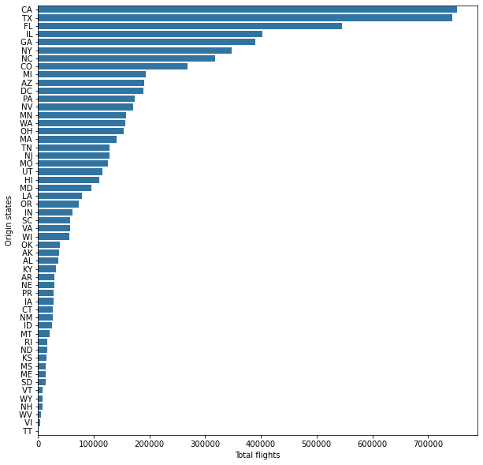

```python
state_orig = df_clean['ORIGIN_STATE'].value_counts()
order = state_orig.index

plt.figure(figsize=(10,10))

sb.countplot(data=df_clean, y='ORIGIN_STATE', order=order, color=global_color)
plt.ylabel("Origin states")
plt.xlabel("Total flights");
```

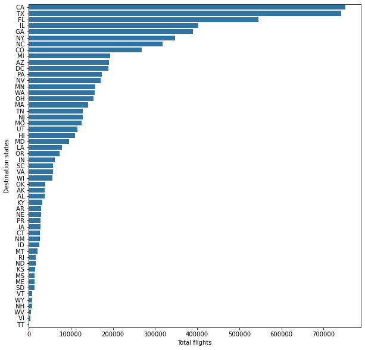

```python
state_dest = df_clean['DEST_STATE'].value_counts()
order = state_dest.index

plt.figure(figsize=(10,10))

sb.countplot(data=df_clean, y='DEST_STATE', order=order, color=global_color)
plt.ylabel("Destination states")
plt.xlabel("Total flights");
```

All origin state positions are equal to destination state positions. The assert function bellow confirm.

```python
lst_teste = []
lst_teste.append(state_orig.index == state_dest.index)

for i in lst_teste:
    assert False not in i
```

**Top 10 most common flight stretches**

```python
func = lambda x1, x2: str(x1) + ' x ' + str(x2)
df_clean['STRETCH'] = df_clean.ORIGIN_STATE.combine(df_clean.DEST_STATE, func=func)
```

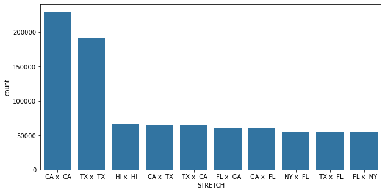

```python
flight_stretch = df_clean['STRETCH'].value_counts().head(10)
order = flight_stretch.index

plt.figure(figsize=(10,5))

sb.countplot(data=df_clean, x='STRETCH', order=order, color=global_color);
```

Florida state is in 5 of the 10 most common stretches, while it is only the third for flights of origin and destination.

**Delay reason**

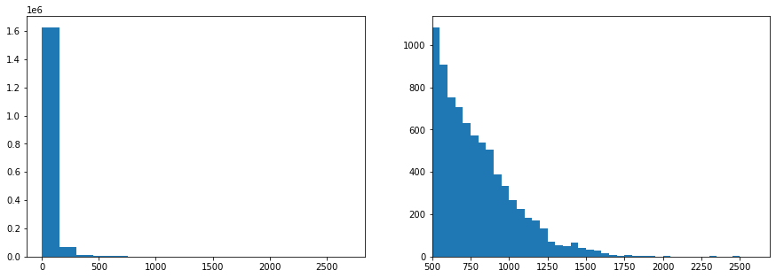

```python
plt.figure(figsize=(15,5))

plt.subplot(1,2,1)
bin_edge = np.arange(delay_reason.TOTAL_DELAY_REASON.min(), delay_reason.TOTAL_DELAY_REASON.max()+150,150)
plt.hist(delay_reason['TOTAL_DELAY_REASON'], bins=bin_edge)

plt.subplot(1,2,2)
bin_edge = np.arange(500,delay_reason.TOTAL_DELAY_REASON.max()+50,50)
plt.xlim((500, delay_reason.TOTAL_DELAY_REASON.max()))
plt.hist(delay_reason['TOTAL_DELAY_REASON'], bins=bin_edge);
```

The delays are concentred in first values of histogram, what is good because the client not stay long time waiting. The right plot is zoom result of the end of left plot. When delays are highs, the values are in 500 to 750 minutes, thats mean 8.3 to 12.5 hours of delay.

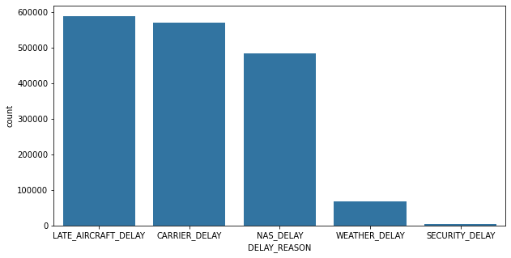

```python
plt.figure(figsize=(10,5))
delay_reasons_count = delay_reason['DELAY_REASON'].value_counts()
order = delay_reasons_count.index
sb.countplot(data=delay_reason, x='DELAY_REASON', order=order, color=global_color);
```

**Air time**

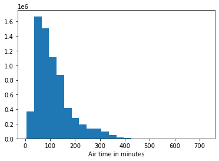

```python
#plt.subplot(1,3,1)
bin_edges = np.arange(df_clean['AIR_TIME'].min(), df_clean['AIR_TIME'].max()+30, 30)
plt.xlabel('Air time in minutes')
plt.hist(df_clean['AIR_TIME'], bins=bin_edges);
```

Histogram of a flight air time shows a right skewed data, with its majority in range 0 to 100. Thats means the majority are quickly flights of approximately 1 hour and 30 minutes (100 minutes is equal to 1.6 hours). No outliers finded.

**Distance**

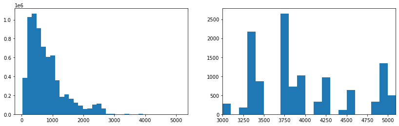

```python
plt.figure(figsize=(14,4))
plt.subplot(1,2,1)
bin_edges = np.arange(df_clean['DISTANCE'].min(), df_clean['DISTANCE'].max()+150 ,150)
plt.hist(df_clean['DISTANCE'], bins=bin_edges);

plt.subplot(1,2,2)
bin_edges = np.arange(3000, df_clean['DISTANCE'].max()+100 ,100)
plt.xlim((3000,df_clean['DISTANCE'].max()))
plt.hist(df_clean['DISTANCE'], bins=bin_edges);
```

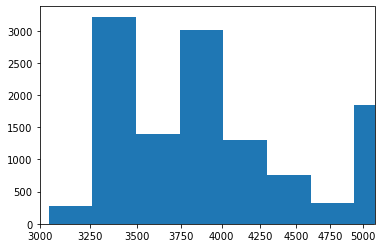

```python
log_max = np.log10(df_clean.query("DISTANCE > 3000")['DISTANCE'].describe()[7])
log_min = np.log10(df_clean.query("DISTANCE > 3000")['DISTANCE'].describe()[3])

bin_edges = 10 ** np.arange(log_min, log_max+0.03 ,0.03)
ticks = [3000,3250, 3500, 3750, 4000, 4250, 4500, 4750,5000]
labels = ['{}'.format(v) for v in ticks]

plt.xlim((10**log_min,10**log_max))
plt.xscale('log')
plt.xticks(ticks, labels)
plt.hist(df_clean['DISTANCE'], bins=bin_edges, color=global_color);
plt.show();
```

Some outliers above 3000 miles. In the graph on the right, these outliers are explored in more detail and in the graph above, a log scale was applied to normalize the distribution. There is a spike in flights within outliers to locations between 3250 and 3500 miles and 3750 and 4000 miles.

**Carrier names**

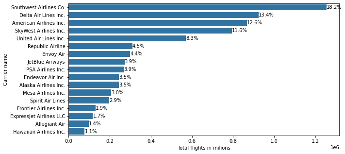

```python
carrier_counts = df_clean['CARRIER_NAME'].value_counts()
order = carrier_counts.index

plt.figure(figsize=(10,5))
sb.countplot(data=df_clean, y='CARRIER_NAME', order=order, color=global_color);

for i in range(carrier_counts.shape[0]):
    count = carrier_counts[i]
    pct_string = '{:0.1f}%'.format(100 * count / total_flights)
    plt.text(x=count+1, y=i, s=pct_string, va='center')

plt.ylabel("Carrier name")
plt.xlabel("Total flights in milions");
```

It is impressive to note that the airline that has the most flights in the period represents only 18% of the total, a fact that demonstrates fierce competition between carriers.

**Cancelled flights**

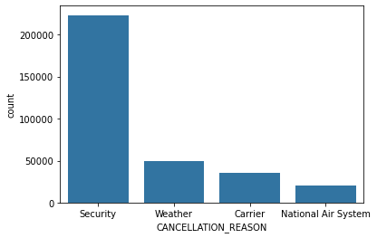

```python
order = df_cancelled['CANCELLATION_REASON'].value_counts().index
sb.countplot(data=df_cancelled, x='CANCELLATION_REASON', order=order, color=global_color);
```

This plot can be transformed to a relationship visualization of cancelled flights reasons over the months, with a time series plot because have a strange thing in data labeled as Security with much more counts in relation with others reasons.

### Discuss the distribution(s) of your variable(s) of interest. Were there any unusual points? Did you need to perform any transformations?

- All origin state positions are equal to destination state positions, so I apply assert function to check if this result is true.
- Zoom in Delay reason variable with x limit to check how the higher delays comported.
- Some outliers in Distance variable, then I need to apply log scale to deep into this outliers.
- Security with much more counts in relation with others cancelled reasons

### Of the features you investigated, were there any unusual distributions? Did you perform any operations on the data to tidy, adjust, or change the form of the data? If so, why did you do this?

- Removed canceled flights from the main dataframe
- Applied melt function to extract main reasons of flight delays
- Function to concatenate origin state with destination state to get the flight stretches
- All the code in section 3, "Basic clean" went to tidy, adjust, or change the form of the data

## Bivariate Exploration

**Cancelled and not cancelled flights by year**

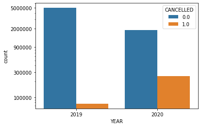

```python
ticks = [100000, 300000, 900000, 2000000, 5000000]
labels = ['{}'.format(v) for v in ticks]

sb.countplot(data=df, x='YEAR', hue='CANCELLED')
plt.yscale('log')
plt.yticks(ticks, labels)
plt.show();
```

Value 1.0 are cancelled flights. In four first months of 2020 year, the total of cancelled flights has already exceeded eight months of 2019 year.

**How flights are distributed in week days**

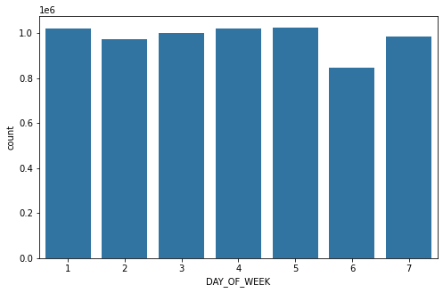

```python
week_count = df_clean['DAY_OF_WEEK'].value_counts(sort=False)

plt.figure(figsize=(8,5))
sb.countplot(data=df_clean, x='DAY_OF_WEEK', color=global_color);
```

Most flights are in friday while on saturday it has less demands.

**Distance x Air time**

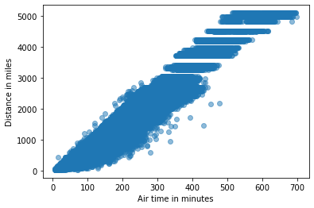

```python
plt.scatter(x=df_clean['AIR_TIME'], y=df_clean['DISTANCE'], alpha=1/2)
plt.xlabel('Air time in minutes')
plt.ylabel('Distance in miles');
```

A strong positive relationship between distance and air time variables, that means how much high distance, air time is higher too.

**Air time by carriers**

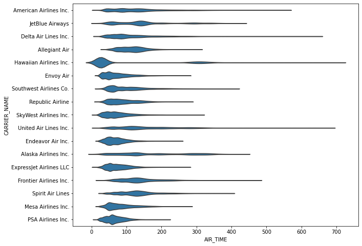

```python
plt.figure(figsize=(10,8))
sb.violinplot(data=df_clean, x='AIR_TIME', y='CARRIER_NAME', color=global_color, inner=None)
```

Hawaiian Airlines caught my attention because it is the last one in relation to the total number of flights made, but in terms of air time, it is in fifth place and has the longest air time registered in relation to the others.

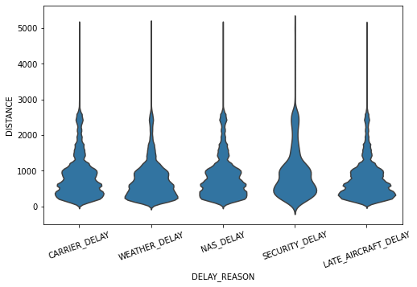

```python
plt.figure(figsize=(8,5))
plt.xticks(rotation=20)
sb.violinplot(data=delay_reason, x='DELAY_REASON', y='DISTANCE', inner=None, color=global_color);
```

## Multivariate Exploration

**Correlation matrix**

Plot to see main relationships between variables of dataframe.

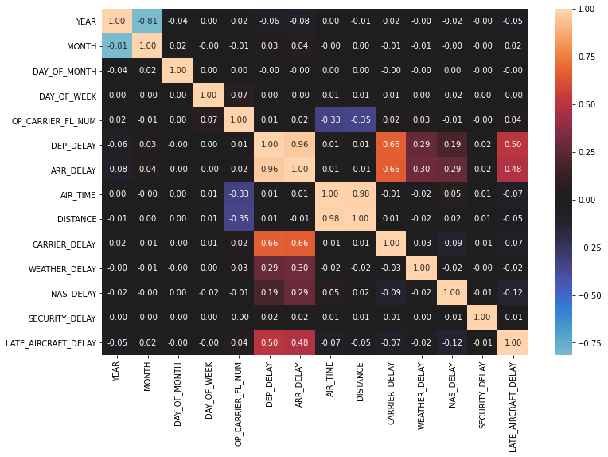

```python
columns = ['YEAR','MONTH','DAY_OF_MONTH','DAY_OF_WEEK','OP_CARRIER_FL_NUM','DEP_DELAY',
           'ARR_DELAY','AIR_TIME','DISTANCE','CARRIER_DELAY','WEATHER_DELAY','NAS_DELAY',
           'SECURITY_DELAY','LATE_AIRCRAFT_DELAY']

plt.figure(figsize=(12,8))
corr_matrix = df_clean[columns].corr()
sb.heatmap(data=corr_matrix, annot=True, fmt='.2f', center=0);
```

**Distance x Air time between carriers**

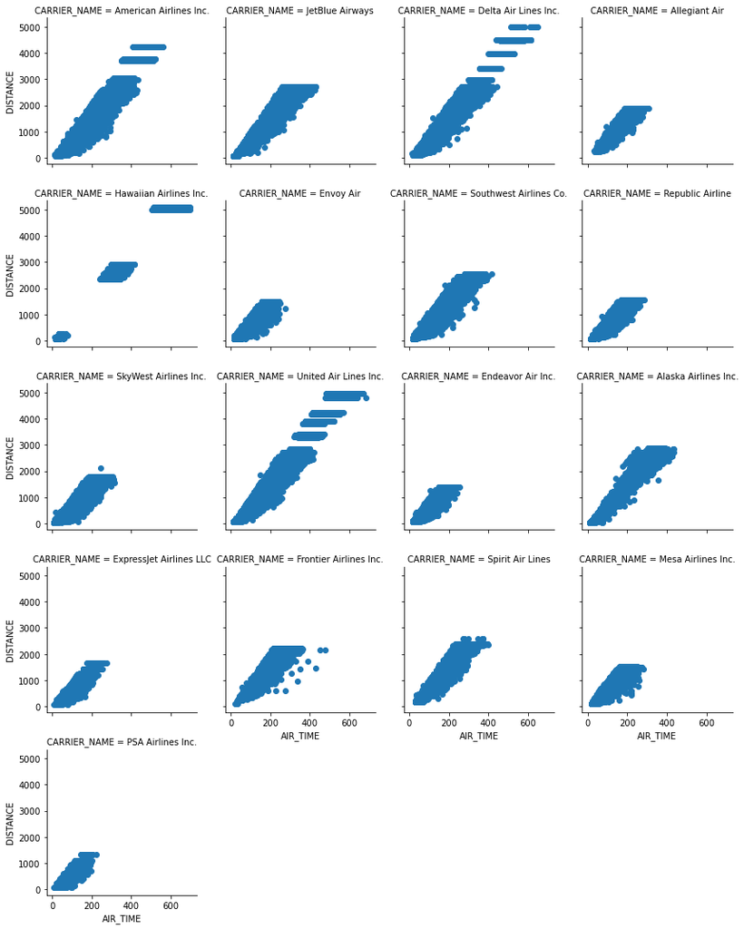

```python
g = sb.FacetGrid(data=df_clean, col='CARRIER_NAME', margin_titles=True, col_wrap=4)
plt.xlabel("Air time")
g.map(plt.scatter, 'AIR_TIME', 'DISTANCE');
```

Very interesting to note that all of the above graphs form pieces of the air time x distance scatter plot. Once again the carrier Hawaiian Airlines draws attention for making short, medium and longest flights among all other operators. This FacetGrid is just a different way to display the violin chart "Air time by carriers".

**Time series plot: Cancellation reasons along months**

```python
concat_func = lambda x,y: str(x) + '-' + str(y)
df_cancelled['MONTH_YEAR'] = df_cancelled.MONTH.combine(df_cancelled.YEAR, func=concat_func)
```

```python
df_cancelled['MONTH_YEAR'] = pd.to_datetime(df_cancelled['MONTH_YEAR'], format='%m-%Y')
```

```python
canc_rs_all = df_cancelled.groupby(['MONTH_YEAR','CANCELLATION_REASON'])['CANCELLATION_REASON'].count()
```

```python
canc_rs_all = canc_rs_all.reset_index(level=['MONTH_YEAR','CANCELLATION_REASON'], name='TOTAL')
```

```python
canc_rs_sec = canc_rs_all.query("CANCELLATION_REASON == 'Security'")
canc_rs = canc_rs_all.drop(canc_rs_all.query("CANCELLATION_REASON == 'Security'").index, axis=0)
canc_rs.reset_index(drop=True, inplace=True)
```

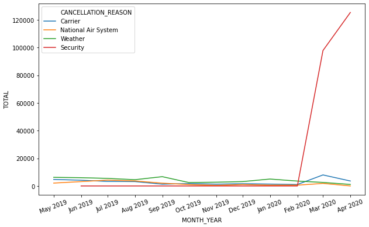

```python
import matplotlib.dates as mdates

fig, ax = plt.subplots(figsize=(10,6))
ax.xaxis.set_major_locator(mdates.AutoDateLocator())
ax.xaxis.set_major_formatter(mdates.DateFormatter('%b %Y'))
plt.xticks(canc_rs_all.MONTH_YEAR.value_counts().index, rotation=20)
sb.lineplot(data=canc_rs_all, x='MONTH_YEAR', y='TOTAL', hue='CANCELLATION_REASON', ax=ax);
```

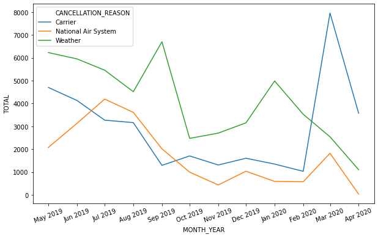

```python
fig, ax = plt.subplots(figsize=(10,6))
ax.xaxis.set_major_locator(mdates.AutoDateLocator())
ax.xaxis.set_major_formatter(mdates.DateFormatter('%b %Y'))
plt.xticks(canc_rs.MONTH_YEAR.value_counts().index, rotation=20)
sb.lineplot(data=canc_rs, x='MONTH_YEAR', y='TOTAL', hue='CANCELLATION_REASON', ax=ax);
```

Interestingly looking at these two charts and that there was a spike in cancellation for security and operator reasons starting in the same period (Feb 2020), two days after a declaration of outbreak of COVID-19 to be a Public Health Emergency of International Concern link.

Many flights canceled by the "Carrier" themselves, but the overwhelming majority for security reasons, which were rarely used in the months before Feb 2020.

### Talk about some of the relationships you observed in this part of the investigation. Were there features that strengthened each other in terms of looking at your feature(s) of interest?

Yes, for example in my initial guess in the univariate exploration section, where I believe there is something strange about the 'CANCELLATION_REASON' variable, with a very big difference in the 'Security' reason compared to the others. Fact that was unveiled when plotting the time series graph.

### Were there any interesting or surprising interactions between features?

It was surprising to note that the plots of air time x distance by the carriers form parts for the general scatter plot of variables distance and air time.